# PSTAT 131 Homework 3

Zhuohao Kris Li

## Classification

For this assignment, we will be working with part of a [Kaggle data set](https://www.kaggle.com/c/titanic/overview) that was the subject of a machine learning competition and is often used for practicing ML models. The goal is classification; specifically, to predict which passengers would survive the [Titanic shipwreck](https://en.wikipedia.org/wiki/Titanic).

Load the data from `data/titanic.csv` into *R* and familiarize yourself with the variables it contains using the codebook (`data/titanic_codebook.txt`).

Notice that `survived` and `pclass` should be changed to factors. When changing `survived` to a factor, you may want to reorder the factor so that *“Yes”* is the first level.

Make sure you load the `tidyverse` and `tidymodels`!

*Remember that you’ll need to set a seed at the beginning of the document to reproduce your results.*

```r
library(tidyverse)
library(tidymodels)
tidymodels_prefer()
library(dplyr)
library(corrplot)
library(klaR)
library(MASS)
library(discrim)
library(caret)
```

```r
set.seed(1203)
titanic <- read_csv(file = "titanic.csv")
titanic$survived = factor(titanic$survived, levels = c("Yes", "No"))
titanic$pclass = factor(titanic$pclass)
```

### Question 1

Split the data, stratifying on the outcome variable, `survived.` You should choose the proportions to split the data into. Verify that the training and testing data sets have the appropriate number of observations. Take a look at the training data and note any potential issues, such as missing data.

Why is it a good idea to use stratified sampling for this data?

```r
p <- 0.75
strats <- titanic$survived

rr <- split(1:length(strats), strats)
index <- sort(as.numeric(unlist(sapply(rr, function(x) sample(x, length(x) * p)))))

train <- titanic[index, ]
test <- titanic[-index, ]

#The original survived distribution:
table(titanic$survived)
```

```
##
## Yes  No
## 342 549
```

```r
#The training survived distribution:
table(train$survived)
```

```
##
## Yes  No
## 256 411
```

```r
#The testing survived distribution:
table(test$survived)
```

```
##
## Yes  No
##  86 138
```

```r
summary(train)
```

```
##   passenger_id   survived  pclass      name               sex
##  Min.   :  1.0   Yes:256   1:158   Length:667         Length:667
##  1st Qu.:221.5   No :411   2:137   Class :character   Class :character
##  Median :431.0             3:372   Mode  :character   Mode  :character
##  Mean   :441.1
##  3rd Qu.:657.5
##  Max.   :891.0
##
##       age            sib_sp           parch           ticket
##  Min.   : 0.42   Min.   :0.0000   Min.   :0.0000   Length:667
##  1st Qu.:21.00   1st Qu.:0.0000   1st Qu.:0.0000   Class :character
##  Median :28.00   Median :0.0000   Median :0.0000   Mode  :character
##  Mean   :29.57   Mean   :0.5142   Mean   :0.3643
##  3rd Qu.:36.88   3rd Qu.:1.0000   3rd Qu.:0.0000
##  Max.   :80.00   Max.   :8.0000   Max.   :6.0000
##  NA's   :129
##       fare            cabin             embarked
##  Min.   :  0.000   Length:667         Length:667
##  1st Qu.:  7.925   Class :character   Class :character
##  Median : 14.454   Mode  :character   Mode  :character
##  Mean   : 31.529
##  3rd Qu.: 30.696
##  Max.   :512.329
##
```

### Question 2

Using the **training** data set, explore/describe the distribution of the outcome variable `survived`.

```r
table(train$survived)
```

```
##
## Yes  No
## 256 411
```

```r
table(train$survived)/nrow(train)
```

```
##
##       Yes        No
## 0.3838081 0.6161919
```

The class size of ‘No’ (411 observations, 62% of total) is about 1.5 times the size of ‘Yes’ (256 observations; 38% of total).

### Question 3

Using the **training** data set, create a correlation matrix of all continuous variables. Create a visualization of the matrix, and describe any patterns you see. Are any predictors correlated with each other? Which ones, and in which direction?

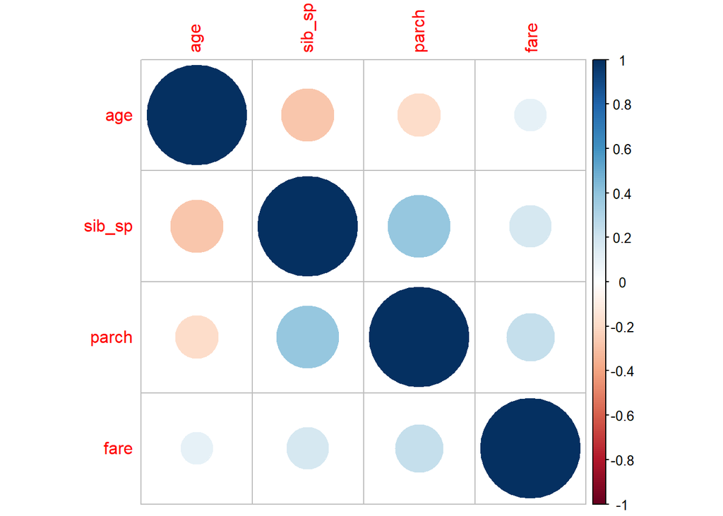

```r
train_cont <- dplyr::select(train, where(is.numeric), -passenger_id)
train_M <- cor(train_cont, use = "complete.obs")
corrplot(train_M)
```

sib_sp and age has an negative relationship with a pearson correlation coefficient around -0.3;

parch and sib_sp has a positive relationship with a pearson correlation coefficient around 0.4.

### Question 4

Using the **training** data, create a recipe predicting the outcome variable `survived`. Include the following predictors: ticket class, sex, age, number of siblings or spouses aboard, number of parents or children aboard, and passenger fare.

Recall that there were missing values for `age`. To deal with this, add an imputation step using `step_impute_linear()`. Next, use `step_dummy()` to **dummy** encode categorical predictors. Finally, include interactions between:

- Sex and passenger fare, and
- Age and passenger fare.

You’ll need to investigate the `tidymodels` documentation to find the appropriate step functions to use.

```r
rec <- recipe(survived ~ pclass + sex + age + sib_sp + parch + fare, data = train)
step_impute_linear(rec, age, impute_with = imp_vars(sib_sp))
```

```
## Recipe
##
## Inputs:
##
##       role #variables
##    outcome          1
##  predictor          6
##
## Operations:
##
## Linear regression imputation for age
```

```r
step_dummy(rec, all_nominal_predictors())
```

```
## Recipe
##
## Inputs:
##
##       role #variables
##    outcome          1
##  predictor          6
##
## Operations:
##
## Dummy variables from all_nominal_predictors()
```

```r
step_interact(rec, ~ sex:age + age:fare)
```

```
## Recipe
##
## Inputs:
##
##       role #variables
##    outcome          1
##  predictor          6
##
## Operations:
##
## Interactions with sex:age + age:fare
```

### Question 5

Specify a **logistic regression** model for classification using the `"glm"` engine. Then create a workflow. Add your model and the appropriate recipe. Finally, use `fit()` to apply your workflow to the **training** data.

*Hint: Make sure to store the results of `fit()`. You’ll need them later on.*

```r
mod5 <- logistic_reg(engine = "glm", mode = "classification")
workflow5 <- workflow(rec, mod5)
fit5 <- fit(workflow5, train)
```

### Question 6

**Repeat Question 5**, but this time specify a linear discriminant analysis model for classification using the `"MASS"` engine.

```r
mod6 <- discrim_linear(engine = "MASS", mode = "classification")
workflow6 <- workflow(rec, mod6)
fit6 <- fit(workflow6, train)
```

### Question 7

**Repeat Question 5**, but this time specify a quadratic discriminant analysis model for classification using the `"MASS"` engine.

```r
mod7 <- discrim_quad(engine = "MASS", mode = "classification")
workflow7 <- workflow(rec, mod7)
fit7 <- fit(workflow7, train)
```

### Question 8

**Repeat Question 5**, but this time specify a naive Bayes model for classification using the `"klaR"` engine. Set the `usekernel` argument to `FALSE`.

```r
mod8 <- naive_Bayes() %>%
  set_mode("classification") %>%
  set_engine("klaR") %>%
  set_args(usekernel = FALSE)
workflow8 <- workflow(rec, mod8)
# fit8 <- fit(workflow8, train)
# Error in if (any(temp)) stop("Zero variances for at least one class in variables: ", : missing value where TRUE/FALSE needed
```

### Question 9

Now you’ve fit four different models to your training data.

Use `predict()` and `bind_cols()` to generate predictions using each of these 4 models and your **training** data. Then use the *accuracy* metric to assess the performance of each of the four models.

Which model achieved the highest accuracy on the training data?

```r
mod5_pred <- predict(fit5, new_data = train)
bind_cols(mod5_pred, train$survived)
```

```
## # A tibble: 667 x 2
##    .pred_class ...2
##    <fct>       <fct>
##  1 No          No
##  2 Yes         Yes
##  3 Yes         Yes
##  4 Yes         Yes
##  5 No          No
##  6 <NA>        No
##  7 Yes         Yes
##  8 Yes         Yes
##  9 Yes         Yes
## 10 Yes         Yes
## # ... with 657 more rows
```

```r
accuracy(mod5_pred,truth = train$survived, estimate = .pred_class)
```

```
## # A tibble: 1 x 3
##   .metric  .estimator .estimate
##   <chr>    <chr>          <dbl>
## 1 accuracy binary         0.801
```

```r
mod6_pred <- predict(fit6, new_data = train)
bind_cols(mod6_pred, train$survived)
```

```
## # A tibble: 667 x 2
##    .pred_class ...2
##    <fct>       <fct>
##  1 No          No
##  2 Yes         Yes
##  3 Yes         Yes
##  4 Yes         Yes
##  5 No          No
##  6 <NA>        No
##  7 Yes         Yes
##  8 Yes         Yes
##  9 Yes         Yes
## 10 Yes         Yes
## # ... with 657 more rows
```

```r
accuracy(mod6_pred,truth = train$survived, estimate = .pred_class)
```

```
## # A tibble: 1 x 3
##   .metric  .estimator .estimate
##   <chr>    <chr>          <dbl>
## 1 accuracy binary         0.794
```

```r
mod7_pred <- predict(fit7, new_data = train)
bind_cols(mod7_pred, train$survived)
```

```
## # A tibble: 667 x 2
##    .pred_class ...2
##    <fct>       <fct>
##  1 No          No
##  2 Yes         Yes
##  3 No          Yes
##  4 Yes         Yes
##  5 No          No
##  6 <NA>        No
##  7 No          Yes
##  8 Yes         Yes
##  9 No          Yes
## 10 Yes         Yes
## # ... with 657 more rows
```

```r
accuracy(mod7_pred,truth = train$survived, estimate = .pred_class)
```

```
## # A tibble: 1 x 3
##   .metric  .estimator .estimate
##   <chr>    <chr>          <dbl>
## 1 accuracy binary         0.809
```

The QDA model has the highest accuracy.

### Question 10

Fit the model with the highest training accuracy to the **testing** data. Report the accuracy of the model on the **testing** data.

Again using the **testing** data, create a confusion matrix and visualize it. Plot an ROC curve and calculate the area under it (AUC).

How did the model perform? Compare its training and testing accuracies. If the values differ, why do you think this is so?

```r
fit7_test <- fit(workflow7, test)
pred7_test <- predict(fit7_test, new_data = test)
bind_cols(pred7_test, test$survived)
```

```
## # A tibble: 224 x 2
##    .pred_class ...2
##    <fct>       <fct>
##  1 No          No
##  2 No          No
##  3 No          No
##  4 <NA>        Yes
##  5 Yes         No
##  6 <NA>        Yes
##  7 Yes         No
##  8 <NA>        No
##  9 Yes         Yes
## 10 Yes         Yes
## # ... with 214 more rows
```

```r
accuracy(pred7_test, truth = test$survived, estimate = .pred_class)
```

```
## # A tibble: 1 x 3
##   .metric  .estimator .estimate
##   <chr>    <chr>          <dbl>
## 1 accuracy binary         0.835
```

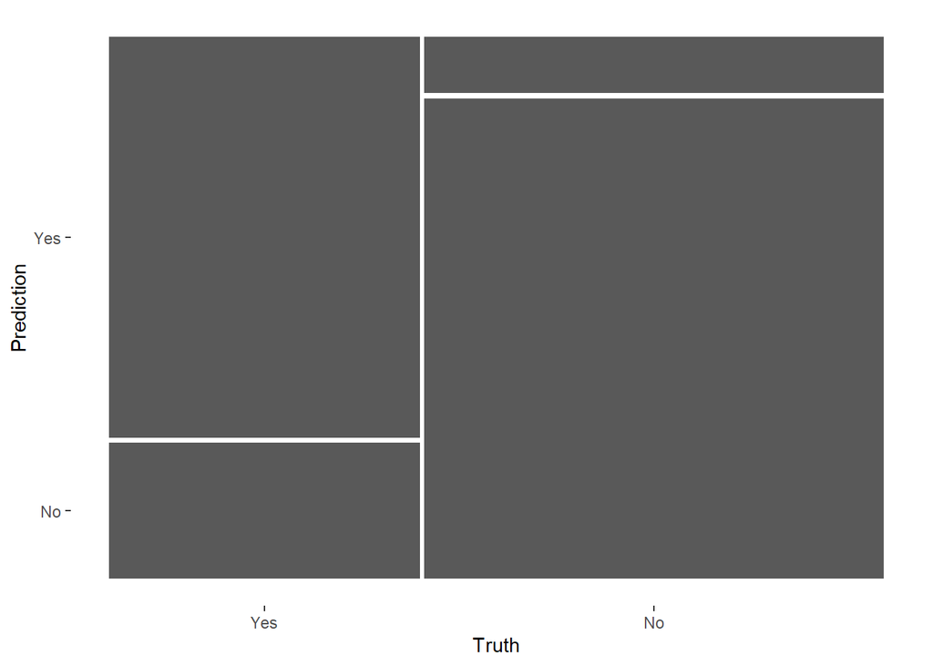

```r
aug <- augment(fit7_test, new_data = test)
conf_matrix <- conf_mat(aug, truth = survived, estimate = .pred_class)
ROC <- roc_curve(aug, test$survived, .pred_Yes)
autoplot(conf_matrix)
```

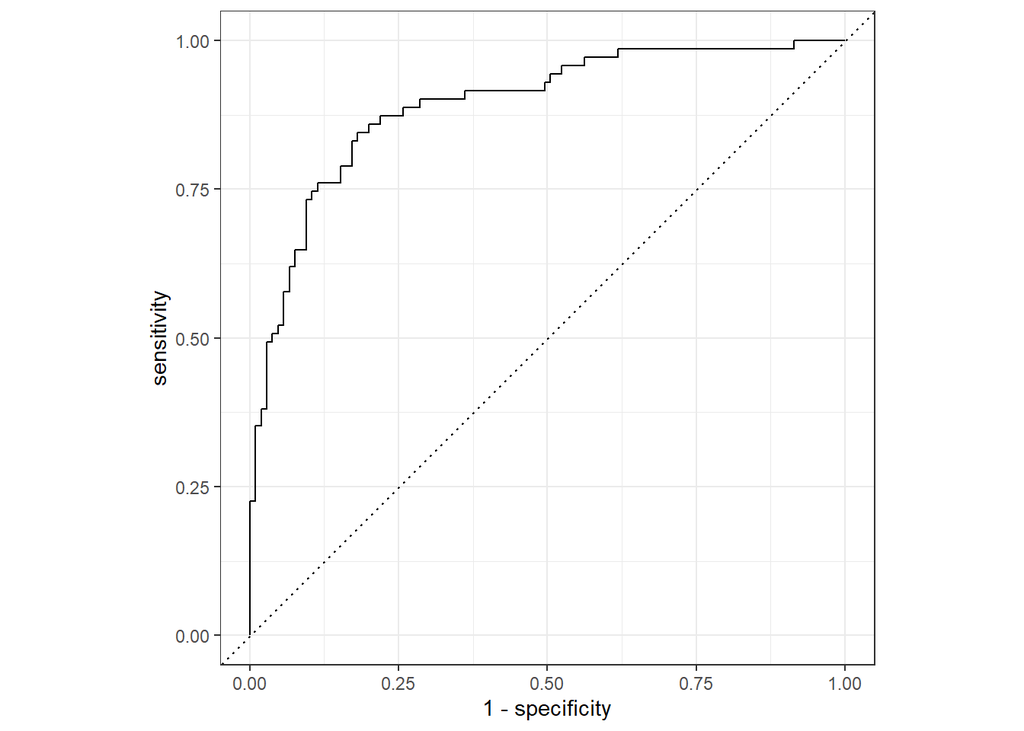

```r
autoplot(ROC)
```

The model is doing pretty well. Its accuracy for the testing set is 0.8352, which is even higher than it was for the training set, which was 0.8086. I think this is probably just by chance, or it’s because the variance in the larger training set in higher and this dataset is a simple one.